# Ricker models for Harrison data

# Ricker simple

Simple Ricker model of the form: $R_{t} = a*S_{t}*exp(-b*S_{t}) *exp(\epsilon_{t})$

$\epsilon \sim N(0,\sigma)$

| parameters | MLE | median | low | high |
| --- | --- | --- | --- | --- |
| a | 3.5816170 | 3.2099506 | 1.8677453 | 6.1433203 |
| b | 0.0000067 | 0.0000056 | 0.0000017 | 0.0000112 |
| $\sigma$ | 0.7976483 | 0.8354127 | 0.6545545 | 1.1129748 |

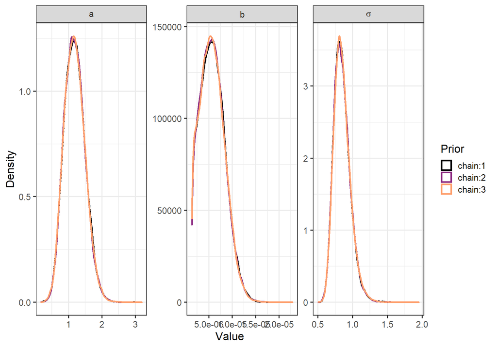

Figure 1. Posterior probability distributions for simple Ricker model.

# Ricker with autocorrelation

Ricker model with autocorrelation in residuals of the form:

$R_t = a*S_t*exp(-b*S_t) *exp(\epsilon_t +\epsilon_{t-1} *\rho)$

$\epsilon \sim N(0,\sigma_{AR})$

$\sigma_{AR} = \sigma * sqrt(1-\rho^2)$

| parameters | MLE | median | low | high |
| --- | --- | --- | --- | --- |
| a | 2.9891348 | 2.3879280 | 1.4027093 | 4.9612468 |
| b | 0.0000050 | 0.0000024 | 0.0000002 | 0.0000091 |
| $\sigma_{AR}$ | 0.7743725 | 0.8257473 | 0.6462057 | 1.1031295 |
| $\rho$ | 0.2182485 | 0.2850157 | -0.0507778 | 0.5568097 |

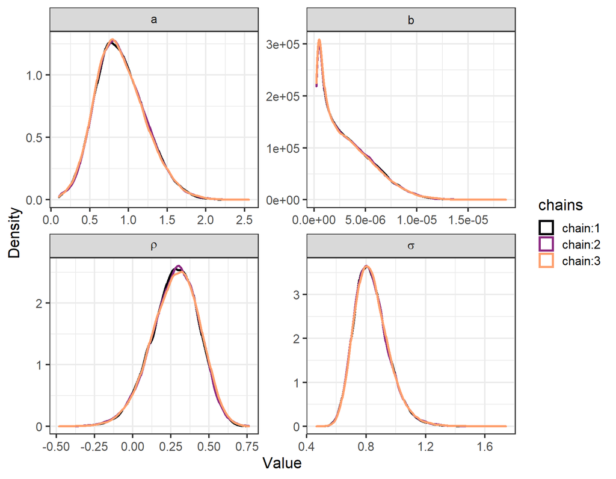

Figure . Posterior probability distributions for Ricker model with autocorrelation.

# Ricker with time-varying productivity

Ricker model with time-varying productivity

$R_t = a_t*S_t*exp(-b*S_t) *exp(\epsilon_t )$

$a_t = a_{t-1} + v_t$

$\epsilon \sim N(0,\sigma)$

$v \sim N(0,\sigma_{a})$

$\sigma_{tot}= sqrt(\sigma^2 + \sigma_{a}^2)$

Parameter estimates for model with time-varying productivity.

| parameters | MLE | median | low | high |
| --- | --- | --- | --- | --- |
| a_[2010] | 1.9228743 | 1.7172607 | 0.7669224 | 3.9919712 |
| a_[2011] | 1.9369770 | 1.7715989 | 0.7687292 | 4.2620060 |
| a_[2012] | 1.6048443 | 1.4579871 | 0.6435668 | 3.4080784 |
| a_[2013] | 1.5152228 | 1.4027681 | 0.5763193 | 3.5334110 |
| a_[avg4] | 1.7347871 | 1.5793751 | 0.6838257 | 3.7833481 |
| b | 0.0000060 | 0.0000048 | 0.0000016 | 0.0000099 |
| $\sigma_{tot}$ | 0.7161689 | 0.5813497 | 0.3543158 | 1.0393352 |

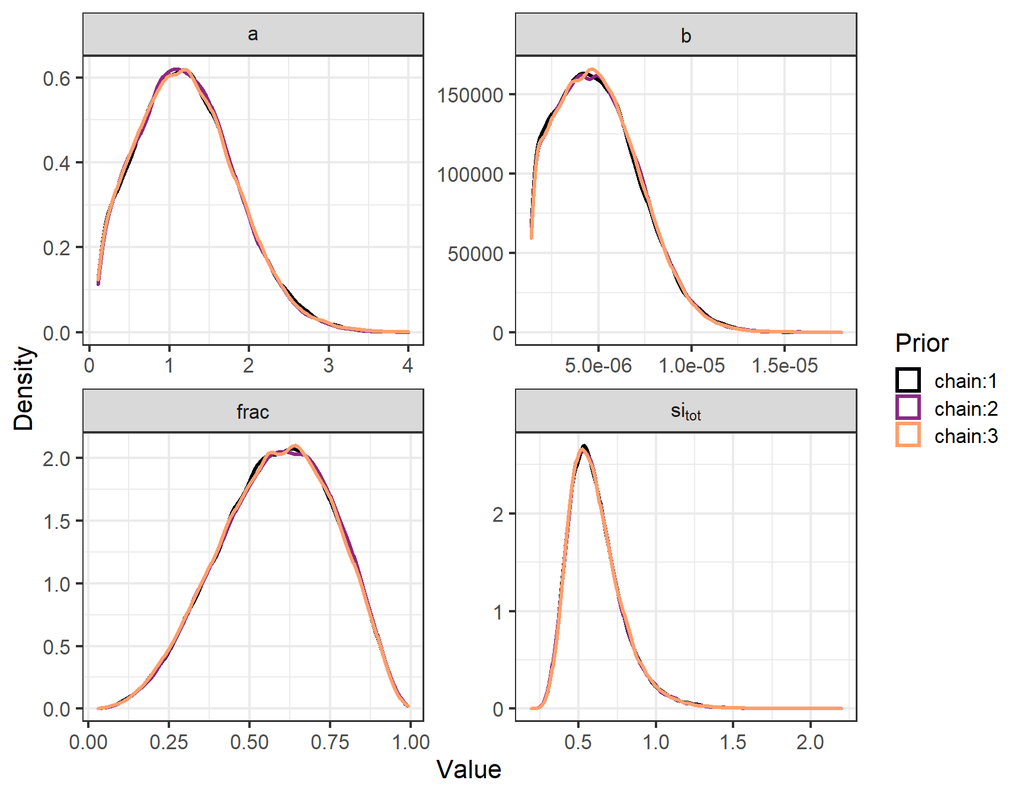

# Ricker model with smolt to age 2 survival as covariate

In this model we use survival as part of the model. In this version, the classic productivity parameter is replaced by $a*surv_t$

$R_t = a*surv_t*S_t*exp(-b*S_t) *exp(\epsilon)$

$\epsilon \sim N(0,\sigma)$

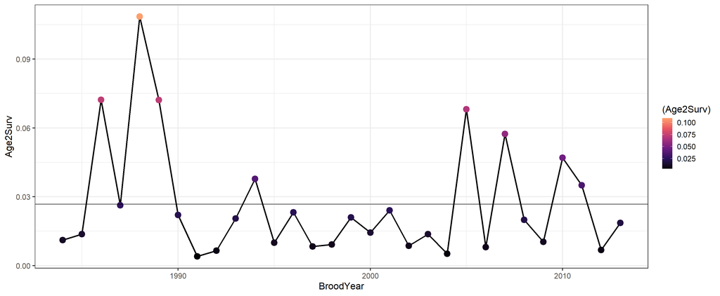

Figure. Survival to age two estimates.

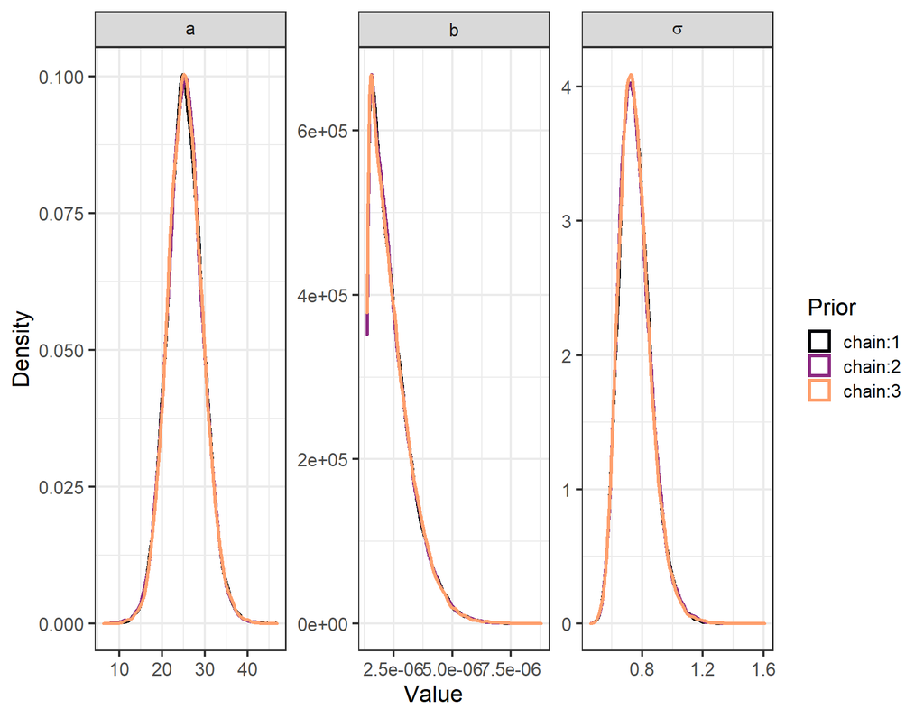

Figure. Posterior probability distributions for Ricker with survival as a covariate.

Parameter estimates for model with survival from smolt to age 2 as a covariate.

| parameters | MLE | median | low | high |
| --- | --- | --- | --- | --- |
| a[2010] | 3.1201516 | 3.2839685 | 2.2627956 | 4.9038255 |
| a[2011] | 2.3334752 | 2.4241106 | 1.8369511 | 3.2675948 |
| a[2012] | 1.1789564 | 1.1877172 | 1.1254090 | 1.2586564 |
| a[2013] | 1.5687994 | 1.6008924 | 1.3814940 | 1.8761846 |
| a[avg] | 2.0503456 | 2.1241722 | 1.6516624 | 2.8265653 |
| b | 0.0000018 | 0.0000022 | 0.0000014 | 0.0000046 |
| $\sigma$ | 0.7171434 | 0.7447275 | 0.5849511 | 0.9968441 |

# Ricker model with smolt to age 2 survival and fecundity as covariates

In this version of the model we describe the ricker productivity as function of two covariates. The survival index and a fecundity index. We use z-scores for these covariates.

$R_t = a_t*S_t*exp(-b*S_t) *exp(\epsilon)$

$a_t = a_0+ \gamma_1*surv_t \gamma_2 * fec_t$

$\epsilon \sim N(0,\sigma)$

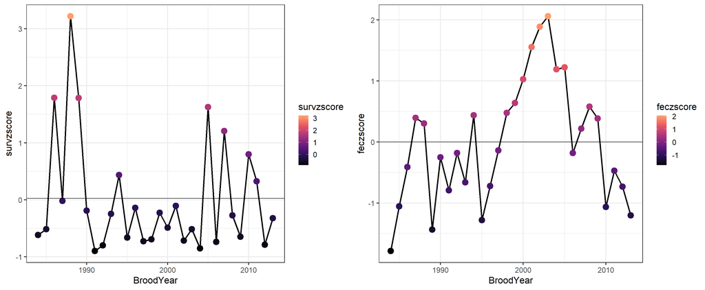

Figure. z-scores for fecundity and survival covariates

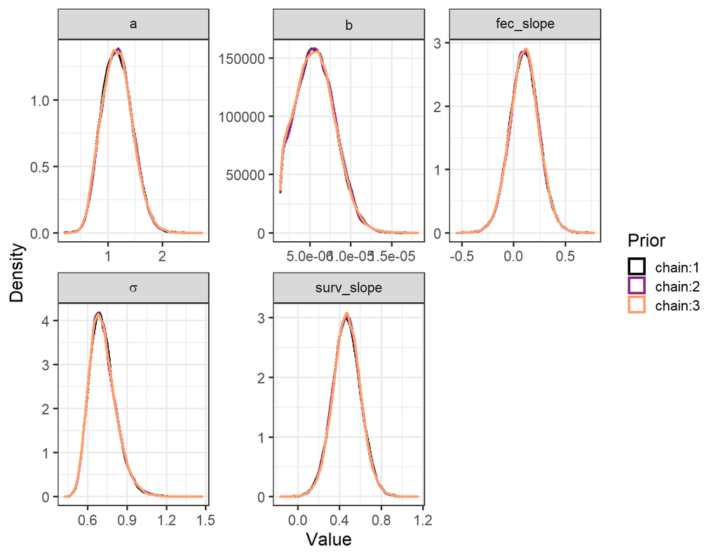

Figure. Posterior probability distributions for Ricker with survival and fecundity as a covariates.

Parameter estimates for model with survival as a covariate.

| parameters | MLE | median | low | high |
| --- | --- | --- | --- | --- |
| a[2010] | 4.4848625 | 4.1761776 | 2.3952471 | 7.4710910 |
| a[2011] | 3.8652709 | 3.5438328 | 2.1740475 | 6.1544564 |
| a[2012] | 2.2438235 | 2.0596737 | 1.1793051 | 3.7800330 |
| a[2013] | 2.6305726 | 2.4428754 | 1.4024795 | 4.3975095 |
| a[avg4] | 3.3061324 | 3.0556399 | 1.7877698 | 5.4507725 |
| b | 0.0000066 | 0.0000056 | 0.0000017 | 0.0000106 |
| $\sigma$ | 0.6481577 | 0.7053511 | 0.5482321 | 0.9527378 |
| surv_sl | 0.4620528 | 0.4660666 | 0.2004416 | 0.7343025 |
| fec_sl | 0.1180155 | 0.1017382 | -0.1773587 | 0.3811135 |

# Ricker model with egg to age 2 survival as covariate

In this model we use survival from egg to age 2 as part of the model. In this version, similarly to the model using the smolt to age 2 survival estimates, the classic productivity parameter is replaced by $a*surv_t$

$R_t = a*surv_t*S_t*exp(-b*S_t) *exp(\epsilon)$

$\epsilon \sim N(0,\sigma)$

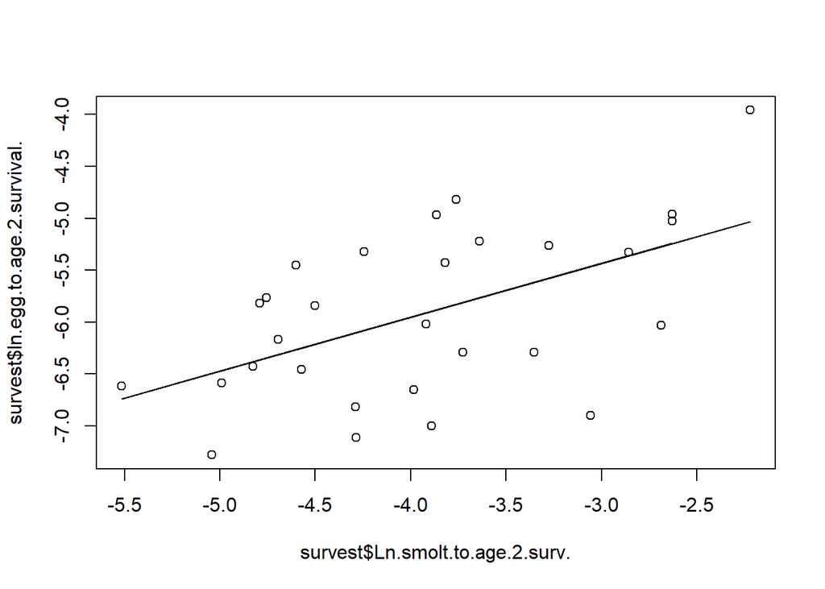

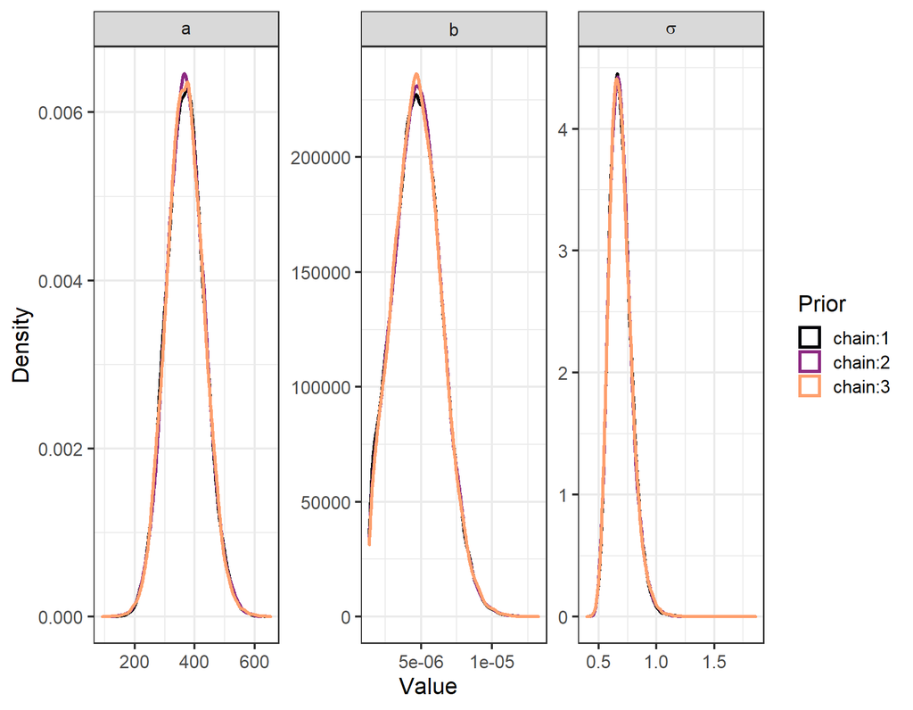

Figure. Posterior probability distributions for Ricker with survival from egg to age 2 as a covariate.

Parameter estimates for model with survival as a covariate.

| parameters | MLE | median | low | high |
| --- | --- | --- | --- | --- |
| a[2010] | 5.0898389 | 4.7518682 | 2.8668157 | 8.1269911 |
| a[2011] | 4.0412683 | 3.8098534 | 2.4691997 | 6.0385547 |
| a[2012] | 1.8152625 | 1.7701337 | 1.4709343 | 2.1547765 |
| a[2013] | 2.7333476 | 2.6197267 | 1.9170871 | 3.6498457 |
| a[avg] | 3.4199293 | 3.2378955 | 2.1810092 | 4.9925420 |
| b | 0.0000053 | 0.0000047 | 0.0000018 | 0.0000082 |
| $\sigma$ | 0.6461706 | 0.6782429 | 0.5313605 | 0.9060559 |

# Comparison

Model comparison was based on visual inspection of temporal residual patterns as well as calculated AIC values for the maximum likelihood estimates. Of all the models considered, the state-space model with time-varying productivity is the one with the lowest residual values and absence of a temporal pattern (refer to resid fig). The AIC values, however, indicate that the model that include survival from egg to age 2 as a covariate is the one with the olowest AIC value, despite of more marked emporal residuals resulting from that fit.

These statistical diagnostics are informative of how the model fits the data, but provide little insight on the potential performance of these models for management advice (Walters and Martell 2004). More recently in the fisheries science literature, there has been a push to base model selection for management advice on closed-loop simulation and managent strategy evaluation analyses (Butterworth 2007; Punt et al. 2016). These analyses are beyond the scope of the current RPA, but efforts to establish a MSE process for Chinook salmon in BC are ongoing.

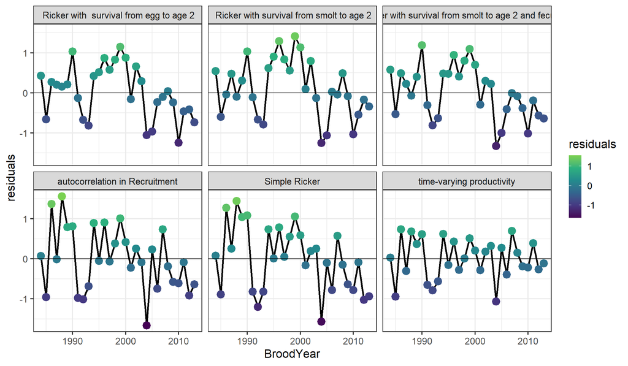

Figure . Residual vs. Brood year comparison over years with all models.

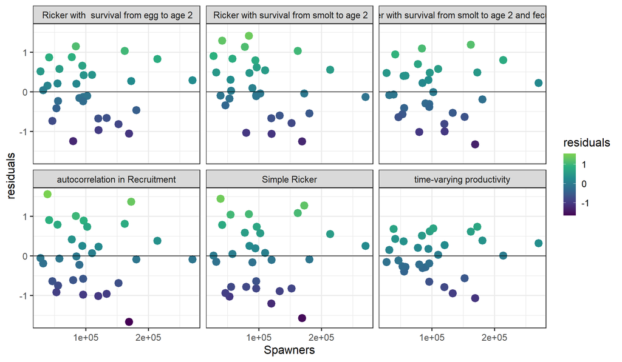

Figure . Residuals vs Spawners comparison over years with all models.

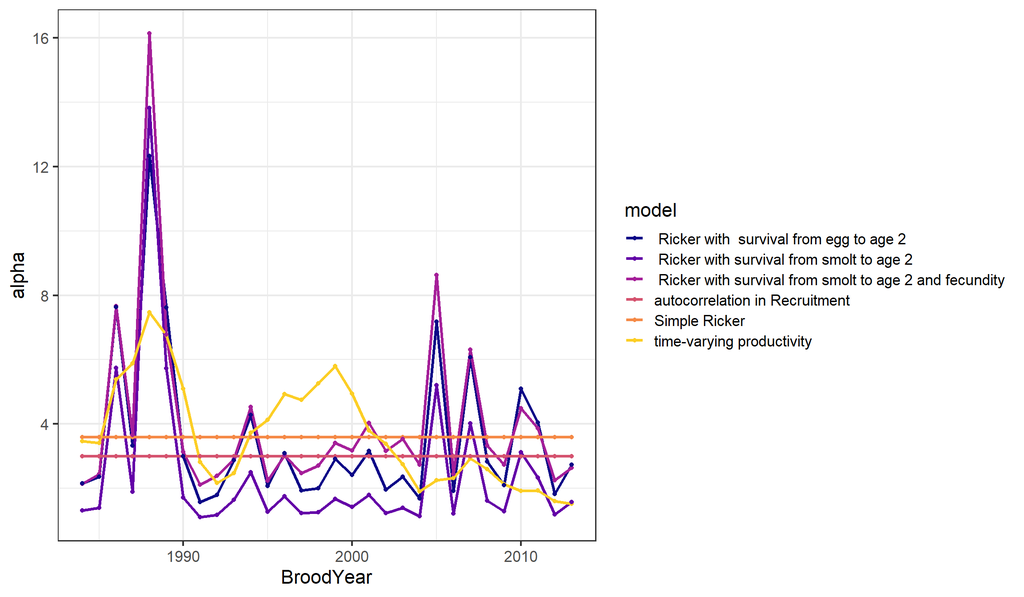

Figure . Productivity comparison with all models.

| model | AIC | deltaAIC |
| --- | --- | --- |
| simple ricker | 77.57106 | 12.636252 |
| autocorrelation in Recruitment | 77.84298 | 12.908171 |
| time-varying productivity | 80.54305 | 15.608235 |
| Ricker with survival from smolt to age 2 as a covariate | 71.18754 | 6.252730 |
| Ricker with survival from smolt to age 2 and fecundity covariates | 69.11903 | 4.184221 |
| Ricker with survival from egg to age 2 as a covariate | 64.93481 | 0.000000 |

# References

Butterworth, Doug S. 2007. “Why a Management Procedure Approach? Some Positives and Negatives.” *ICES Journal of Marine Science* 64 (4): 613–17. https://doi.org/10.1093/icesjms/fsm003.

Punt, André E, Doug S Butterworth, Carryn L de Moor, José A A De Oliveira, and Malcolm Haddon. 2016. “Management Strategy Evaluation: Best Practices.” *Fish and Fisheries*, 303–34. https://doi.org/10.1111/faf.12104.

Walters, Carl J., and Steven J. D. Martell. 2004. *Fisheries Ecology and Management*. Princeton University Press.